# Import Libraries

```python
#importing necessary basic libraries
import pandas as pd
import numpy as np
import matplotlib.pyplot as plt
import seaborn as sns
from sklearn.metrics import accuracy_score
from sklearn.model_selection import train_test_split
```

# Reading the file

```python
#reading the dataset using pandas library
data =df=pd.read_csv('C:/Users/HP/OneDrive/Desktop/Train.csv', header=0)
data
```

|  | index | encounter_id | patient_id | race | gender | age | weight | time_in_hospital | medical_specialty | num_lab_procedures | ... | X19 | X20 | X21 | X22 | X23 | X24 | X25 | change | diabetesMed | readmitted |
| --- | --- | --- | --- | --- | --- | --- | --- | --- | --- | --- | --- | --- | --- | --- | --- | --- | --- | --- | --- | --- | --- |
| 0 | 69375 | 197029140 | 51521940 | Hispanic | Male | [80-90) | ? | 4 | Emergency/Trauma | 39 | ... | No | No | No | No | No | No | No | No | Yes | 1 |
| 1 | 57272 | 163571946 | 92631357 | Caucasian | Male | [60-70) | ? | 3 | Emergency/Trauma | 34 | ... | No | No | No | No | No | No | No | No | No | 0 |
| 2 | 82347 | 256497366 | 30023982 | Caucasian | Female | [50-60) | ? | 6 | Nephrology | 50 | ... | No | Down | No | No | No | No | No | Ch | Yes | 1 |
| 3 | 89608 | 289891212 | 93606021 | AfricanAmerican | Female | [70-80) | ? | 5 | ? | 63 | ... | No | Down | No | No | No | No | No | Ch | Yes | 1 |
| 4 | 24091 | 81873900 | 23464296 | Caucasian | Male | [70-80) | ? | 9 | Psychiatry | 17 | ... | No | No | No | No | No | No | No | No | No | 1 |
| ... | ... | ... | ... | ... | ... | ... | ... | ... | ... | ... | ... | ... | ... | ... | ... | ... | ... | ... | ... | ... | ... |
| 66582 | 39934 | 124202466 | 23450508 | Caucasian | Female | [70-80) | ? | 11 | InternalMedicine | 40 | ... | No | Steady | No | No | No | No | No | No | Yes | 0 |
| 66583 | 47366 | 145667070 | 29324601 | Caucasian | Male | [80-90) | ? | 4 | ? | 39 | ... | No | No | No | No | No | No | No | No | No | 1 |
| 66584 | 76555 | 231061116 | 2179062 | Caucasian | Female | [60-70) | ? | 2 | ? | 24 | ... | No | No | No | No | No | No | No | No | Yes | 1 |
| 66585 | 25392 | 84911682 | 20531754 | ? | Female | [80-90) | ? | 4 | InternalMedicine | 39 | ... | No | No | No | No | No | No | No | No | No | 0 |
| 66586 | 51312 | 153167502 | 81985473 | Caucasian | Female | [80-90) | ? | 2 | ? | 38 | ... | No | Steady | No | No | No | No | No | Ch | Yes | 1 |

66587 rows × 49 columns

```python
data.head(5)
```

|  | index | encounter_id | patient_id | race | gender | age | weight | time_in_hospital | medical_specialty | num_lab_procedures | ... | X19 | X20 | X21 | X22 | X23 | X24 | X25 | change | diabetesMed | readmitted |
| --- | --- | --- | --- | --- | --- | --- | --- | --- | --- | --- | --- | --- | --- | --- | --- | --- | --- | --- | --- | --- | --- |
| 0 | 69375 | 197029140 | 51521940 | Hispanic | Male | [80-90) | ? | 4 | Emergency/Trauma | 39 | ... | No | No | No | No | No | No | No | No | Yes | 1 |
| 1 | 57272 | 163571946 | 92631357 | Caucasian | Male | [60-70) | ? | 3 | Emergency/Trauma | 34 | ... | No | No | No | No | No | No | No | No | No | 0 |
| 2 | 82347 | 256497366 | 30023982 | Caucasian | Female | [50-60) | ? | 6 | Nephrology | 50 | ... | No | Down | No | No | No | No | No | Ch | Yes | 1 |
| 3 | 89608 | 289891212 | 93606021 | AfricanAmerican | Female | [70-80) | ? | 5 | ? | 63 | ... | No | Down | No | No | No | No | No | Ch | Yes | 1 |
| 4 | 24091 | 81873900 | 23464296 | Caucasian | Male | [70-80) | ? | 9 | Psychiatry | 17 | ... | No | No | No | No | No | No | No | No | No | 1 |

5 rows × 49 columns

```python
data.tail(5)
```

|  | index | encounter_id | patient_id | race | gender | age | weight | time_in_hospital | medical_specialty | num_lab_procedures | ... | X19 | X20 | X21 | X22 | X23 | X24 | X25 | change | diabetesMed | readmitted |
| --- | --- | --- | --- | --- | --- | --- | --- | --- | --- | --- | --- | --- | --- | --- | --- | --- | --- | --- | --- | --- | --- |
| 66582 | 39934 | 124202466 | 23450508 | Caucasian | Female | [70-80) | ? | 11 | InternalMedicine | 40 | ... | No | Steady | No | No | No | No | No | No | Yes | 0 |
| 66583 | 47366 | 145667070 | 29324601 | Caucasian | Male | [80-90) | ? | 4 | ? | 39 | ... | No | No | No | No | No | No | No | No | No | 1 |
| 66584 | 76555 | 231061116 | 2179062 | Caucasian | Female | [60-70) | ? | 2 | ? | 24 | ... | No | No | No | No | No | No | No | No | Yes | 1 |
| 66585 | 25392 | 84911682 | 20531754 | ? | Female | [80-90) | ? | 4 | InternalMedicine | 39 | ... | No | No | No | No | No | No | No | No | No | 0 |
| 66586 | 51312 | 153167502 | 81985473 | Caucasian | Female | [80-90) | ? | 2 | ? | 38 | ... | No | Steady | No | No | No | No | No | Ch | Yes | 1 |

5 rows × 49 columns

```python
data.sample(5)
```

|  | index | encounter_id | patient_id | race | gender | age | weight | time_in_hospital | medical_specialty | num_lab_procedures | ... | X19 | X20 | X21 | X22 | X23 | X24 | X25 | change | diabetesMed | readmitted |
| --- | --- | --- | --- | --- | --- | --- | --- | --- | --- | --- | --- | --- | --- | --- | --- | --- | --- | --- | --- | --- | --- |
| 12121 | 20367 | 71813418 | 3954060 | Caucasian | Male | [60-70) | ? | 5 | ? | 38 | ... | No | No | No | No | No | No | No | Ch | Yes | 0 |
| 13379 | 12242 | 49985394 | 104602275 | Caucasian | Male | [80-90) | ? | 2 | InternalMedicine | 67 | ... | No | No | No | No | No | No | No | No | No | 0 |
| 17895 | 83286 | 260517270 | 92577789 | Caucasian | Female | [60-70) | ? | 3 | Orthopedics | 29 | ... | No | Steady | No | No | No | No | No | No | Yes | 1 |
| 61013 | 6350 | 31599858 | 57260610 | Caucasian | Female | [90-100) | [50-75) | 3 | ? | 68 | ... | No | Steady | No | No | No | No | No | No | Yes | 0 |
| 47209 | 25026 | 84146676 | 6883434 | Caucasian | Male | [30-40) | ? | 2 | ? | 33 | ... | No | No | No | No | No | No | No | No | No | 1 |

5 rows × 49 columns

```python
data.describe()
```

|  | index | encounter_id | patient_id | time_in_hospital | num_lab_procedures | num_procedures | num_medications | number_outpatient | number_emergency | number_inpatient | diag_5 | number_diagnoses | readmitted |
| --- | --- | --- | --- | --- | --- | --- | --- | --- | --- | --- | --- | --- | --- |
| count | 66587.000000 | 6.658700e+04 | 6.658700e+04 | 66587.000000 | 66587.000000 | 66587.000000 | 66587.000000 | 66587.000000 | 66587.000000 | 66587.000000 | 66587.000000 | 66587.000000 | 66587.000000 |
| mean | 50903.474282 | 1.653153e+08 | 5.422970e+07 | 4.397510 | 43.115533 | 1.331521 | 16.028744 | 0.365672 | 0.200460 | 0.637602 | 49.703387 | 7.424948 | 0.462012 |
| std | 29480.255515 | 1.030035e+08 | 3.878819e+07 | 2.980995 | 19.630417 | 1.705746 | 8.125304 | 1.221861 | 0.905503 | 1.255487 | 28.864879 | 1.933061 | 0.498559 |
| min | 0.000000 | 1.573800e+04 | 1.350000e+02 | 1.000000 | 1.000000 | 0.000000 | 1.000000 | 0.000000 | 0.000000 | 0.000000 | 0.000283 | 1.000000 | 0.000000 |
| 25% | 25166.500000 | 8.440328e+07 | 2.338646e+07 | 2.000000 | 31.000000 | 0.000000 | 10.000000 | 0.000000 | 0.000000 | 0.000000 | 24.622056 | 6.000000 | 0.000000 |
| 50% | 51129.000000 | 1.528504e+08 | 4.526103e+07 | 4.000000 | 44.000000 | 1.000000 | 15.000000 | 0.000000 | 0.000000 | 0.000000 | 49.508499 | 8.000000 | 0.000000 |
| 75% | 76380.000000 | 2.305049e+08 | 8.727185e+07 | 6.000000 | 57.000000 | 2.000000 | 20.000000 | 0.000000 | 0.000000 | 1.000000 | 74.637294 | 9.000000 | 1.000000 |
| max | 101765.000000 | 4.438672e+08 | 1.893494e+08 | 14.000000 | 129.000000 | 6.000000 | 81.000000 | 39.000000 | 63.000000 | 19.000000 | 99.995810 | 16.000000 | 1.000000 |

```python
data.info()
```

```
<class 'pandas.core.frame.DataFrame'>
RangeIndex: 66587 entries, 0 to 66586
Data columns (total 49 columns):
 #   Column              Non-Null Count  Dtype
---  ------              --------------  -----
 0   index               66587 non-null  int64
 1   encounter_id        66587 non-null  int64
 2   patient_id          66587 non-null  int64
 3   race                66587 non-null  object
 4   gender              66587 non-null  object
 5   age                 66587 non-null  object
 6   weight              66587 non-null  object
 7   time_in_hospital    66587 non-null  int64
 8   medical_specialty   66587 non-null  object
 9   num_lab_procedures  66587 non-null  int64
```

[output cut: 41 more lines]

# Data Cleaning Process

```python
#removal of  unwanted features
data = data.drop(['index','patient_id','race','weight','medical_specialty'],axis = 1)
```

```python
data.nunique()
```

```
encounter_id          48911
gender                    3
age                      10
time_in_hospital         14
num_lab_procedures      113
num_procedures            7
num_medications          71
number_outpatient        33
number_emergency         26
number_inpatient         19
diag_1                  652
diag_2                  656
diag_3                  707
diag_4                  707
diag_5                48911
number_diagnoses         16
X1                        4
X2                        4
X3                        4
X4                        4
X5                        4
X6                        3
X7                        4
X8                        1
X9                        4
X10                       4
X11                       2
X12                       4
X13                       4
X14                       4
X15                       3
X16                       2
X17                       2
X18                       1
X19                       1
X20                       4
X21                       4
X22                       2
X23                       2
X24                       2
X25                       1
change                    2
diabetesMed               2
readmitted                2
dtype: int64
```

```python
data.isnull().sum()
```

```
encounter_id          0
gender                0
age                   0
time_in_hospital      0
num_lab_procedures    0
num_procedures        0
num_medications       0
number_outpatient     0
number_emergency      0
number_inpatient      0
diag_1                0
diag_2                0
diag_3                0
diag_4                0
diag_5                0
number_diagnoses      0
X1                    0
X2                    0
X3                    0
X4                    0
X5                    0
X6                    0
X7                    0
X8                    0
X9                    0
X10                   0
X11                   0
X12                   0
X13                   0
X14                   0
X15                   0
X16                   0
X17                   0
X18                   0
X19                   0
X20                   0
X21                   0
X22                   0
X23                   0
X24                   0
X25                   0
change                0
diabetesMed           0
readmitted            0
dtype: int64
```

```python
#converting intervals to integer values
Age = []
for i in data['age']:
  if i == '[80-90)':
    Age.append(85)
  elif i == '[60-70)':
    Age.append(65)
  elif i == '[50-60)':
    Age.append(55)
  elif i == '[70-80)':
    Age.append(75)
  elif i == '[40-50)':
    Age.append(45)
  elif i == '[20-30)':
    Age.append(25)
  elif i == '[30-40)':
    Age.append(35)
  elif i == '[90-100)':
    Age.append(95)
  elif i == '[0-10)':
    Age.append(5)
  else:
    Age.append(15)
```

```python
data['age'] = Age
data.age
```

```
0        85
1        65
2        55
3        75
4        75
         ..
66582    75
66583    85
66584    65
66585    85
66586    85
Name: age, Length: 66587, dtype: int64
```

```python
#converting string and float values to integer
data['diag_1'] =  pd.to_numeric(data['diag_1'].apply(lambda x: np.nan if x[0].isnumeric() == False else x))
data['diag_2'] =  pd.to_numeric(data['diag_2'].apply(lambda x: np.nan if x[0].isnumeric() == False else x))
data['diag_3'] =  pd.to_numeric(data['diag_3'].apply(lambda x: np.nan if x[0].isnumeric() == False else x))
data['diag_4'] =  pd.to_numeric(data['diag_4'].apply(lambda x: np.nan if x[0].isnumeric() == False else x))

#filling the missing values with mean values
data['diag_1'].fillna(data['diag_1'].mean(), inplace=True)
data['diag_2'].fillna(data['diag_1'].mean(), inplace=True)
data['diag_3'].fillna(data['diag_1'].mean(), inplace=True)
data['diag_4'].fillna(data['diag_1'].mean(), inplace=True)
```

```python
#checking for unique values of X1
data['X1'].unique()
```

```
array(['None', '>200', 'Norm', '>300'], dtype=object)
```

```python
#checking for unique values of X2
data['X2'].unique()
```

```
array(['None', 'Norm', '>8', '>7'], dtype=object)
```

```python
#checking for unique values of X3
data['X3'].unique()
```

```
array(['No', 'Steady', 'Up', 'Down'], dtype=object)
```

```python
#checking for unique values of X4
data['X4'].unique()
```

```
array(['No', 'Steady', 'Up', 'Down'], dtype=object)
```

```python
#checking for unique values of X5
data['X5'].unique()
```

```
array(['No', 'Steady', 'Down', 'Up'], dtype=object)
```

```python
#checking for unique values of X6
data['X6'].unique()
```

```
array(['No', 'Steady', 'Up'], dtype=object)
```

```python
#checking for unique values of X7
data['X7'].unique()
```

```
array(['No', 'Steady', 'Up', 'Down'], dtype=object)
```

```python
#checking for unique values of X8
data['X8'].unique()
```

```
array(['No'], dtype=object)
```

```python
#checking for unique values of X9
data['X9'].unique()
```

```
array(['No', 'Steady', 'Up', 'Down'], dtype=object)
```

```python
#checking for unique values of X10
data['X10'].unique()
```

```
array(['No', 'Down', 'Steady', 'Up'], dtype=object)
```

```python
#checking for unique values of X11
data['X11'].unique()
```

```
array(['No', 'Steady'], dtype=object)
```

```python
#checking for unique values of X12
data['X12'].unique()
```

```
array(['No', 'Steady', 'Down', 'Up'], dtype=object)
```

```python
#checking for unique values of X13
data['X13'].unique()
```

```
array(['Steady', 'No', 'Up', 'Down'], dtype=object)
```

```python
#checking for unique values of X14
data['X14'].unique()
```

```
array(['No', 'Steady', 'Up', 'Down'], dtype=object)
```

```python
#checking for unique values of X15
data['X15'].unique()
```

```
array(['No', 'Down', 'Steady'], dtype=object)
```

```python
#checking for unique values of X16
data['X16'].unique()
```

```
array(['No', 'Steady'], dtype=object)
```

```python
#checking for unique values of X17
data['X17'].unique()
```

```
array(['No', 'Steady'], dtype=object)
```

```python
#checking for unique values of X18
data['X18'].unique()
```

```
array(['No'], dtype=object)
```

```python
#checking for unique values of X19
data['X19'].unique()
```

```
array(['No'], dtype=object)
```

```python
#checking for unique values of X20
data['X20'].unique()
```

```
array(['No', 'Down', 'Up', 'Steady'], dtype=object)
```

```python
#checking for unique values of X21
data['X21'].unique()
```

```
array(['No', 'Steady', 'Down', 'Up'], dtype=object)
```

```python
#checking for unique values of X22
data['X22'].unique()
```

```
array(['No', 'Steady'], dtype=object)
```

```python
#checking for unique values of X23
data['X23'].unique()
```

```
array(['No', 'Steady'], dtype=object)
```

```python
#checking for unique values of X24
data['X24'].unique()
```

```
array(['No', 'Steady'], dtype=object)
```

```python
#checking for unique values of X25
data['X25'].unique()
```

```
array(['No'], dtype=object)
```

```python
data = data.drop(['X6', 'X8', 'X11', 'X15', 'X16', 'X17', 'X18', 'X19', 'X22', 'X23', 'X24', 'X25'], axis=1)
```

```python
data.columns
```

```
Index(['encounter_id', 'gender', 'age', 'time_in_hospital',
       'num_lab_procedures', 'num_procedures', 'num_medications',
       'number_outpatient', 'number_emergency', 'number_inpatient', 'diag_1',
       'diag_2', 'diag_3', 'diag_4', 'diag_5', 'number_diagnoses', 'X1', 'X2',
       'X3', 'X4', 'X5', 'X7', 'X9', 'X10', 'X12', 'X13', 'X14', 'X20', 'X21',
       'change', 'diabetesMed', 'readmitted'],
      dtype='object')
```

```python
unique_vals = ['None', 'Norm', '>8', '>7', '>200', '>300','No', 'Steady', 'Up', 'Down']
```

```python
from sklearn.preprocessing import LabelEncoder
```

```python
le = LabelEncoder()
unique_vals1 = le.fit_transform(unique_vals)
unique_vals1
```

```
array([6, 7, 3, 2, 0, 1, 5, 8, 9, 4], dtype=int64)
```

```python
data.replace(unique_vals, unique_vals1, inplace = True)
```

```python
data.info()
```

```
<class 'pandas.core.frame.DataFrame'>
RangeIndex: 66587 entries, 0 to 66586
Data columns (total 32 columns):
 #   Column              Non-Null Count  Dtype
---  ------              --------------  -----
 0   encounter_id        66587 non-null  int64
 1   gender              66587 non-null  object
 2   age                 66587 non-null  int64
 3   time_in_hospital    66587 non-null  int64
 4   num_lab_procedures  66587 non-null  int64
 5   num_procedures      66587 non-null  int64
 6   num_medications     66587 non-null  int64
 7   number_outpatient   66587 non-null  int64
 8   number_emergency    66587 non-null  int64
 9   number_inpatient    66587 non-null  int64
```

[output cut: 24 more lines]

```python
data['gender'].unique()
```

```
array(['Male', 'Female', 'Unknown/Invalid'], dtype=object)
```

```python
g1 = ['Male', 'Female', 'Unknown/Invalid']
g2 = le.fit_transform(g1)

print(g2)
```

```
[1 0 2]
```

```python
data['gender'].replace(g1, g2, inplace = True)
data['gender'].unique()
```

```
array([1, 0, 2], dtype=int64)
```

```python
data.info()
```

```
<class 'pandas.core.frame.DataFrame'>
RangeIndex: 66587 entries, 0 to 66586
Data columns (total 32 columns):
 #   Column              Non-Null Count  Dtype
---  ------              --------------  -----
 0   encounter_id        66587 non-null  int64
 1   gender              66587 non-null  int64
 2   age                 66587 non-null  int64
 3   time_in_hospital    66587 non-null  int64
 4   num_lab_procedures  66587 non-null  int64
 5   num_procedures      66587 non-null  int64
 6   num_medications     66587 non-null  int64
 7   number_outpatient   66587 non-null  int64
 8   number_emergency    66587 non-null  int64
 9   number_inpatient    66587 non-null  int64
```

[output cut: 24 more lines]

```python
data['change'].unique()
```

```
array([5, 'Ch'], dtype=object)
```

```python
f1 = ['No', 'Ch']
f2 = le.fit_transform(f1)

print(f2)
```

```
[1 0]
```

```python
data.replace(f1,f2,inplace=True)
data['change'].unique()
```

```
array([5, 0], dtype=int64)
```

```python
data.info()
```

```
<class 'pandas.core.frame.DataFrame'>
RangeIndex: 66587 entries, 0 to 66586
Data columns (total 32 columns):
 #   Column              Non-Null Count  Dtype
---  ------              --------------  -----
 0   encounter_id        66587 non-null  int64
 1   gender              66587 non-null  int64
 2   age                 66587 non-null  int64
 3   time_in_hospital    66587 non-null  int64
 4   num_lab_procedures  66587 non-null  int64
 5   num_procedures      66587 non-null  int64
 6   num_medications     66587 non-null  int64
 7   number_outpatient   66587 non-null  int64
 8   number_emergency    66587 non-null  int64
 9   number_inpatient    66587 non-null  int64
```

[output cut: 24 more lines]

```python
#for diabetesMed
data['diabetesMed'].unique()
```

```
array(['Yes', 5], dtype=object)
```

```python
dm1 = ['Yes', 5]
dm2 = le.fit_transform(dm1)

print(dm2)
```

```
[1 0]
```

```python
data['diabetesMed'].replace(dm1, dm2, inplace=True)
data['diabetesMed'].unique()
```

```
array([1, 0], dtype=int64)
```

```python
data.info()
```

```
<class 'pandas.core.frame.DataFrame'>
RangeIndex: 66587 entries, 0 to 66586
Data columns (total 32 columns):
 #   Column              Non-Null Count  Dtype
---  ------              --------------  -----
 0   encounter_id        66587 non-null  int64
 1   gender              66587 non-null  int64
 2   age                 66587 non-null  int64
 3   time_in_hospital    66587 non-null  int64
 4   num_lab_procedures  66587 non-null  int64
 5   num_procedures      66587 non-null  int64
 6   num_medications     66587 non-null  int64
 7   number_outpatient   66587 non-null  int64
 8   number_emergency    66587 non-null  int64
 9   number_inpatient    66587 non-null  int64
```

[output cut: 24 more lines]

Data Preprocessing

Analysing feature 'age'

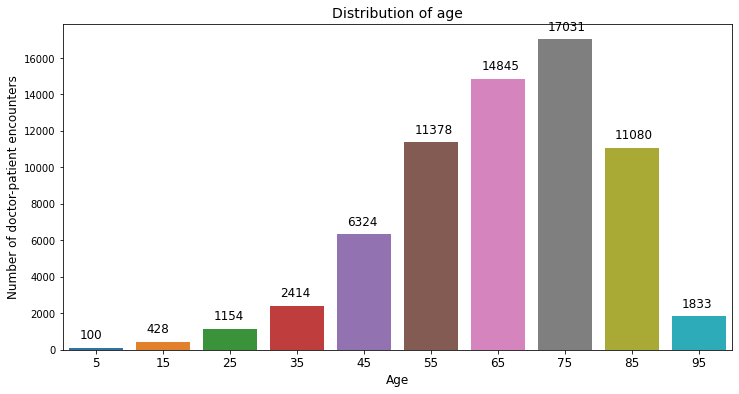

```python
# plotting the count of different values in target variable 'readmitted'
plt.figure(figsize=(12,6))
ax = sns.countplot(x=data['age'])
plt.title('Distribution of age', fontsize=14)
plt.xlabel('Age', fontsize=12)
plt.ylabel('Number of doctor-patient encounters', fontsize=12)
plt.xticks(fontsize=12)

total = len(data['age'])
for p in ax.patches:
    count = '{}'.format(p.get_height())
    x = p.get_x() + .15
    y = p.get_y() + p.get_height() + 500
    ax.annotate(count, (x, y), fontsize=12)

plt.show()
```

Analysing target variable 'readmitted' Our target variable is feature 'readmitted'

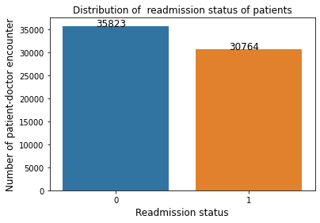

```python
# plotting the count of different values in target variable 'readmitted'
ax = sns.countplot(x=data['readmitted'])
plt.title('Distribution of  readmission status of patients')
plt.xlabel('Readmission status', fontsize=12)
plt.ylabel('Number of patient-doctor encounter', fontsize=12)

for p in ax.patches:
    count = '{}'.format(p.get_height())
    x = p.get_x() + .25
    y = p.get_y() + p.get_height()
    ax.annotate(count, (x, y), fontsize=12)

plt.show()
```

Univariate analysis Univariate analysis of num_lab_procedures

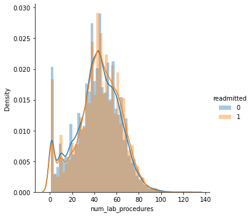

```python
sns.FacetGrid(data,hue='readmitted', size=5 ).map(sns.distplot,'num_lab_procedures').add_legend()
```

```python
mn = data['num_lab_procedures'].mean()
md = data['num_lab_procedures'].median()
print('mean and median of num_lab_procedures is {:.2f} and {:.2f} respectively'.format(mn,md))
```

```
mean and median of num_lab_procedures is 43.12 and 44.00 respectively
```

The distribution of number of lab procedures for both readmitted patients and non-readmitted patients is same but, as these features have considerable variation, they will prove to be useful for model to find patterns in overall complete training data.

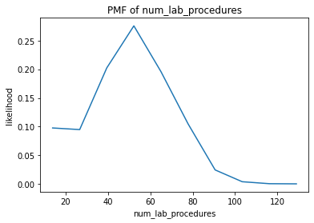

```python
counts, bin_edges = np.histogram(data['num_lab_procedures'], bins=10, density=True)
pdf = counts/sum(counts)
cdf =np.cumsum(pdf)
plt.xlabel('num_lab_procedures')
plt.ylabel('likelihood')
plt.plot(bin_edges[1:], pdf)
plt.title('PMF of num_lab_procedures')
```

Univariate analysis of num_procedures

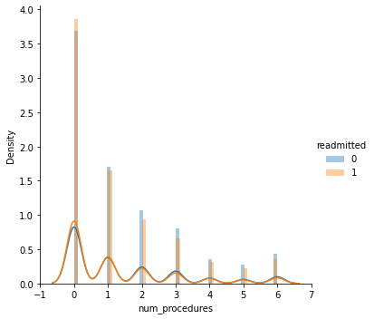

```python
sns.FacetGrid(data,hue='readmitted', size=5 ).map(sns.distplot,'num_procedures').add_legend()
```

Distribution looks almost same for those with reamitted status and otherwise. Number of patient encounters with only 1 lab procedures is significantly more than those with 2,3 or other

```python
_1_ = len(data[(data['readmitted']== 1) & (data['num_procedures'] != 0)])/ len(data[data['readmitted'] == 1])
_0_ = len(data[(data['readmitted']== 0) & (data['num_procedures'] != 0)])/ len(data[data['readmitted'] == 0])
print('Out of total patients that were readmitted {:.2f}% of patients had underwent multiple procedures'.format(_1_))
print('Out of total patients that were NOT readmitted {:.2f}% of patients had underwent multiple procedures'.format(_0_))
```

```
Out of total patients that were readmitted 0.52% of patients had underwent multiple procedures
Out of total patients that were NOT readmitted 0.56% of patients had underwent multiple procedures
```

There is no such relation as almost half of the patients that were readmitted underwent number of medical procedures. Same can be said about those that were not readmitted.

Univariate analysis of 'number_inpatient'

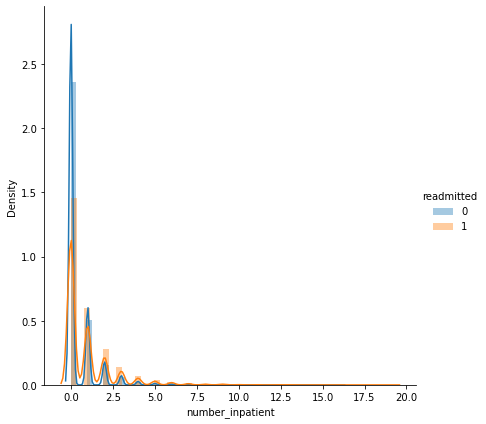

```python
sns.FacetGrid(data,hue='readmitted', size=6 ).map(sns.distplot,'number_inpatient').add_legend()
```

Patients with number_inpatient count as 0 seem to have significantly low readmission rate

```python
per_0_ = len(data[(data['readmitted']== 1) & (data['number_inpatient'] == 0)])/ len(data[data['number_inpatient'] == 0])
per_1_ = len(data[(data['readmitted']== 1) & (data['number_inpatient'] != 0)])/ len(data[data['number_inpatient'] != 0])
print('{:.2f}% of patients with no inpatient history (i.e. never admitted before) were readmitted'.format(100*per_0_))
print('{:.2f}% of patients with inpatient history (i.e. were admitted before) were readmitted'.format(100*per_1_))
```

```
38.66% of patients with no inpatient history (i.e. never admitted before) were readmitted
61.04% of patients with inpatient history (i.e. were admitted before) were readmitted
```

Univariate analysis of 'num_medications' feature

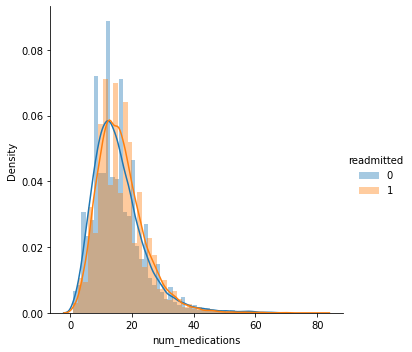

```python
sns.FacetGrid(data,hue='readmitted', size=5 ).map(sns.distplot,'num_medications').add_legend()
```

As we can see, distribution of num of medications is same for both re-admitted and non-readmitted patients. and number of medications mostly ranges in range of 1-30. This is same for both re-admitted as well as non-readmitted patients. Therefore, we can conclude that high number of medications does not necessarily imply poor health or more chances of getting readmitted.

Univariate analysis of gender

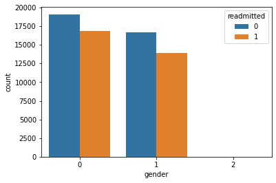

```python
sns.countplot(data["gender"], hue=data['readmitted'])
```

```python
#Creating a Model
x = data.drop('readmitted', axis=1)
y = data['readmitted']
```

```python
from sklearn.model_selection import train_test_split
```

```python
x_train, x_test, y_train, y_test = train_test_split(x, y, test_size=0.3, random_state=100)
```

```python
from sklearn.tree import DecisionTreeClassifier
```

```python
clf = DecisionTreeClassifier()
clf.fit(x_train, y_train)
clf.score(x_test, y_test)
```

```
0.7186764779496421
```

```python
from sklearn.ensemble import RandomForestClassifier
```

```python
rfc = RandomForestClassifier()
rfc.fit(x_train, y_train)
rfc.score(x_test, y_test)
```

```
0.7690343895479802
```

```python
p_test =rfc.predict(x_test)
p_test
```

```
array([0, 0, 0, ..., 0, 0, 0], dtype=int64)
```

```python
from sklearn.metrics import f1_score
f1_score(y_test, p_test)
```

```
0.7351928374655646
```

```python
for i in p_test:
  print(i)
```

[output not shown]

[output cut: 19922 more lines]

[output not shown]

```python
File1=list(zip(x_test['encounter_id'],p_test))
```

```python
File = pd.DataFrame(File1, columns=['encounter_id', 'resdmitted'])
```

```python
File.to_csv('Akshaya_kp_Submission.csv', index=False)
```